# STA426 Homework 2

Yao Yao

01 10 2017

## Exploratory Data Analysis

Do an exploratory data analysis of a matrix of expression values. Load the data and display: * distributions: *boxplot*, *density*, *limma::plotDensities* * normalization: *limma::normalizeQuantiles* * clustering: *hclust* * heatmap: *heatmap.2* or *pheatmap* * correlation matrix: *cor* and *image* * reduced dimensionality representation: *cmdscale* and *prcomp*

## Data Import

```r
anno = read.table("SampleAnnotation.txt", as.is=TRUE, sep="\t", quote="",
                  row.names=1, header=TRUE)
x = read.table("expressiondata.txt", as.is=TRUE, sep="\t", quote="", row.names=1, header=TRUE, check.names = FALSE)
x = as.matrix(x)
```

## Define samples and colors and phenotype

```r
samples = rownames(anno)
colors = rainbow(nrow(anno))
isNorm = anno$TissueType == "norm"
isSick = anno$TissueType == "sick"
isAcute = anno$TissueType == "acute"

colorcluster= anno$TissueType
colorcluster[which(anno$TissueType=="norm")] ="green"
colorcluster[which(anno$TissueType=="sick")] ="yellow"
colorcluster[which(anno$TissueType=="acute")] ="red"

colorclusterlegend <-c("green","yellow","red")
names(colorclusterlegend)<-c("norm","sick","acute")
```

## log transformation and normalization

```r
#all values changed to log values
logvalue <- log(x)
#all log values normalized
normed <- limma::normalizeQuantiles(logvalue)
```

## Distributions in boxplots and densities

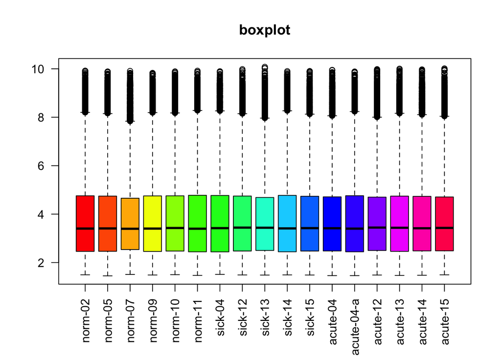

```r
# boxplot
boxplot(logvalue,names=samples,las=2, col=colors, main='boxplot')
```

##### The boxplot shows the overall range and distribution of the gene expression level in each sample. All samples have some outliers that are highly expressed in this experiment.

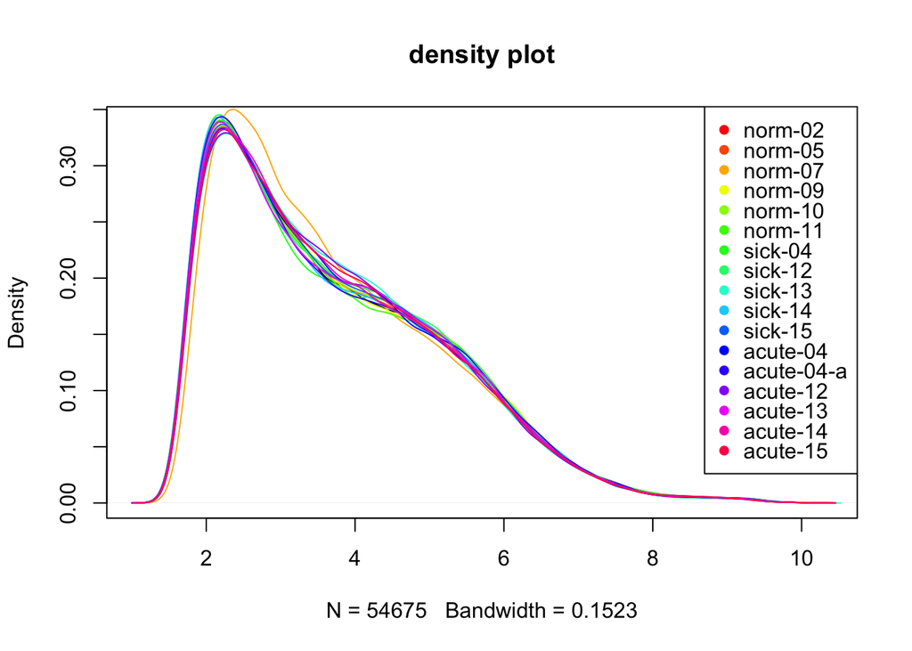

```r
# density
plot(density(logvalue[,1]),main = 'density plot')
for(i in 2:ncol(logvalue)){
  lines(density(logvalue[,i]),main=colnames(logvalue)[i],col=colors[i])
}
legend("topright",col = colors,legend = samples,pch = 16,y.intersp = 0.77)
```

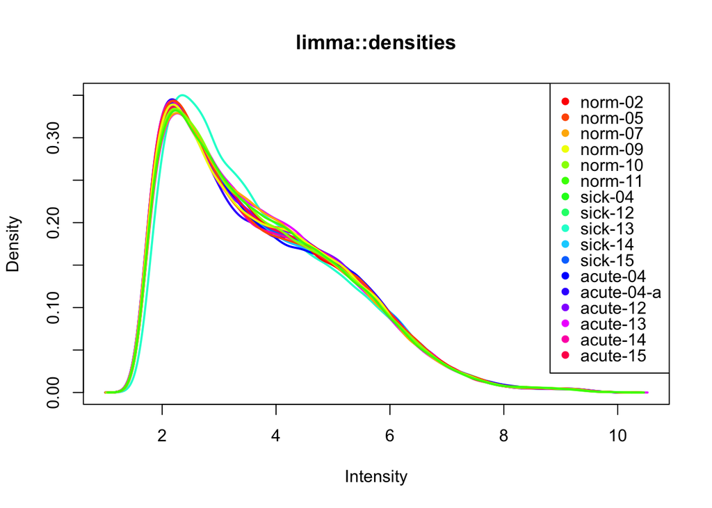

```r
# limma::plotDensities
limma::plotDensities(logvalue,main="limma::densities",col=colors,legend =FALSE)
legend("topright",col= colors, legend= samples, pch=16,y.intersp = 0.78)
```

## Clustering

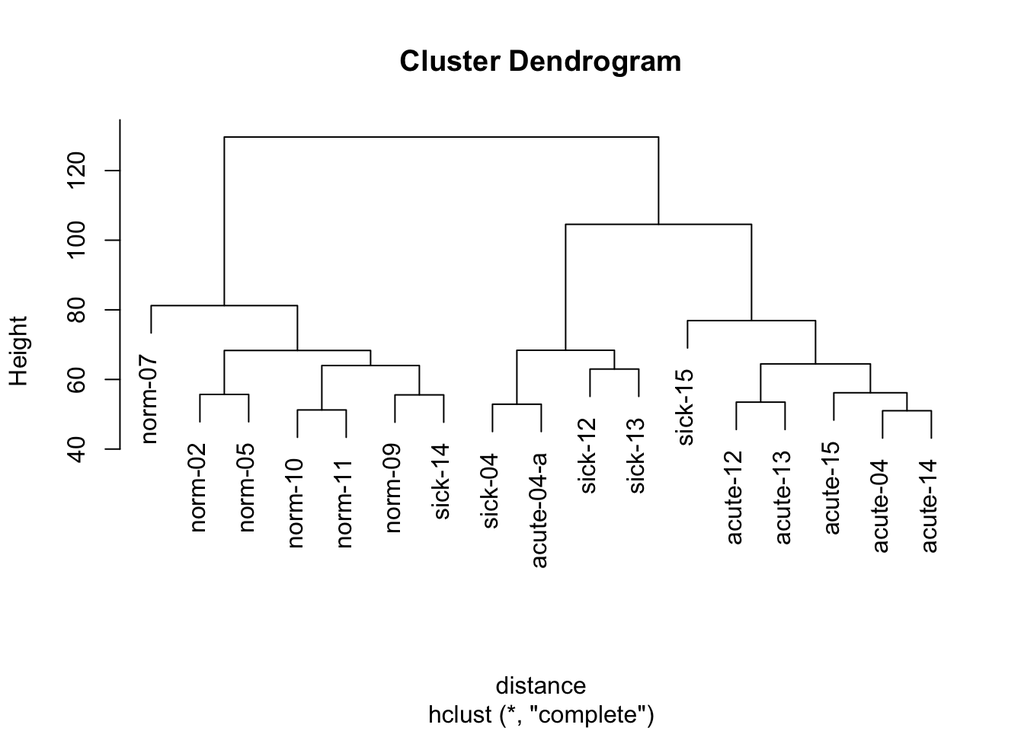

```r
# cluster dendrogram by hclust
distance <- dist(t(normed))
plot(hclust(distance))
```

##### The dendrogram shows the results of a hierarchical clustering analysis of gene expression levels in each sample. Samples in the same category (normal, sick or acute) tend to have closer distance in the cluster dendrogram in this experiment.

## Heatmaps

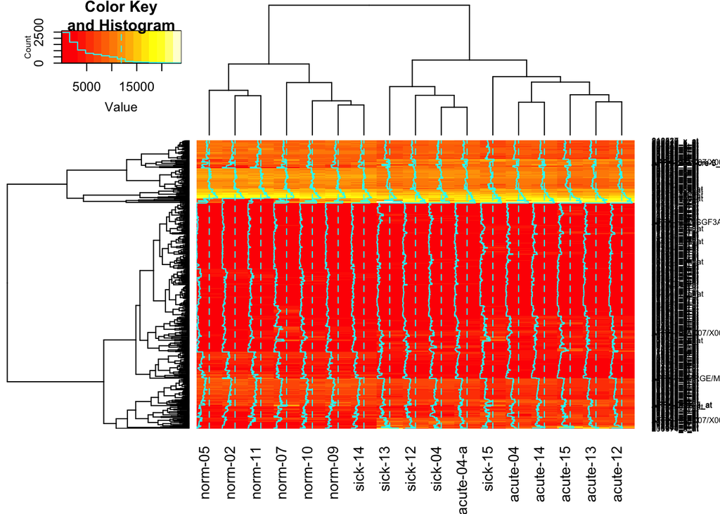

```r
# heatmap.2
library(gplots)
library(genefilter)
rv <- rowVars(x)
orderfilteredgene <- order(-rv)[1:500]
heatmap.2(x[orderfilteredgene,])
```

##### Before drawing the heatmap we pick the 500 genes with the top variances over all samples using genefilter. On top of the heatmap is the dendrogram and on the side is a hierarchical clustering.

## Correlation

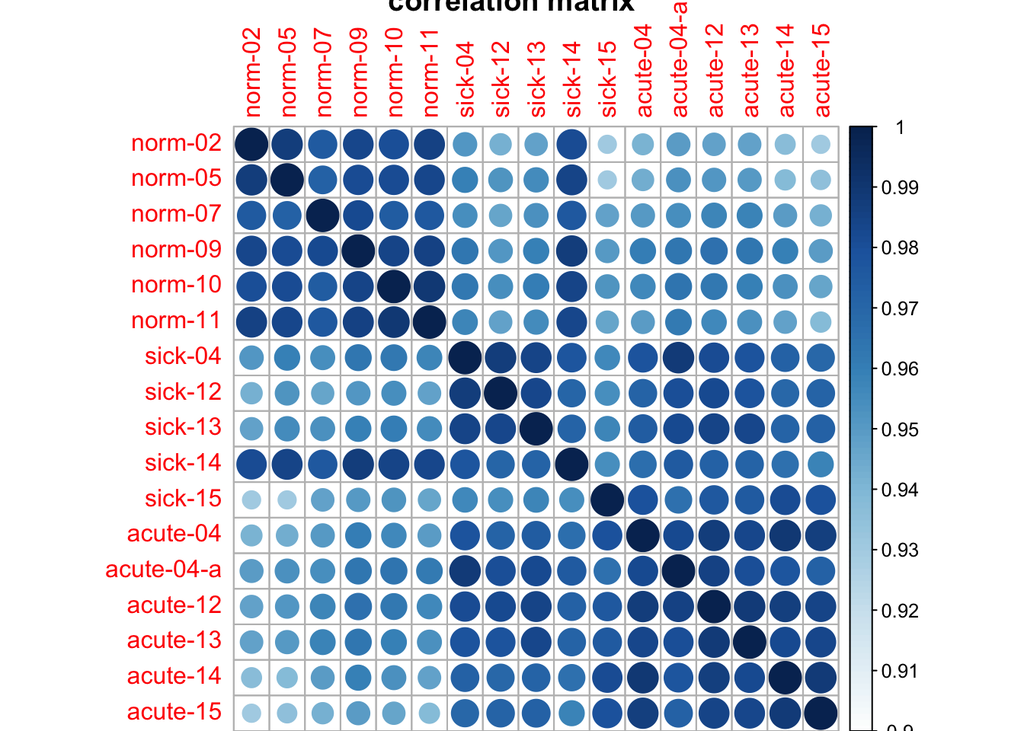

```r
# correlation matrix
cor <- cor(normed)
#corr <- (cor - min(cor))/(max(cor) - min(cor))

# image
library(corrplot)
corrplot(cor,cl.lim=c(0.9,1), main= 'correlation matrix', is.corr=FALSE)
```

## Reduced Dimensionality Representation

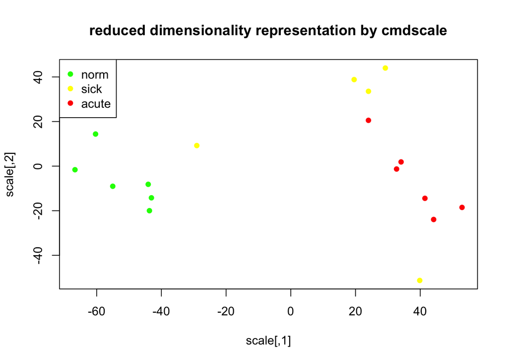

```r
# cmdscale: Classical (Metric) Multidimensional Scaling
scale<-cmdscale(distance,k=2)

plot(scale,col=colorcluster, pch =16, main="reduced dimensionality representation by cmdscale")
legend("topleft",legend = names(colorclusterlegend), col=colorclusterlegend,pch =16)
```

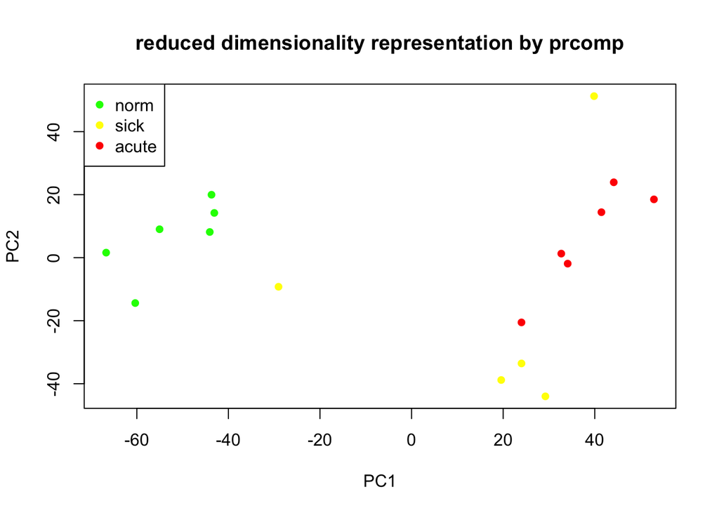

```r
# prcomp: Principal Components Analysis
a<-prcomp(scale)
plot(a$x,col=colorcluster,pch =16,main = "reduced dimensionality representation by prcomp")
legend("topleft",legend = names(colorclusterlegend), col=colorclusterlegend,pch =16)
```